# Analysis and Visualization of Data for Bach Visualization Project

## Factor Score Spearman Rank Correlations

[output not shown]

[output cut: 28 more lines]

[output not shown]

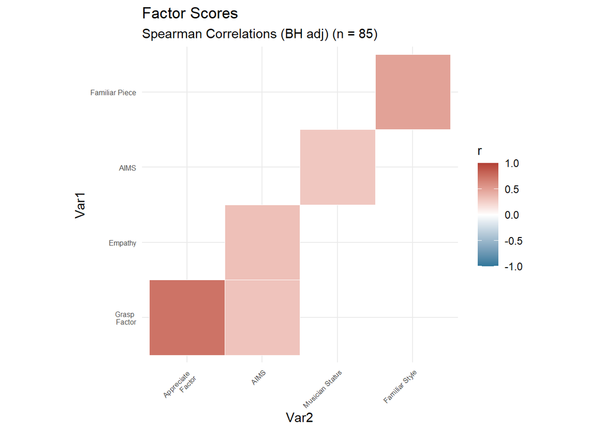

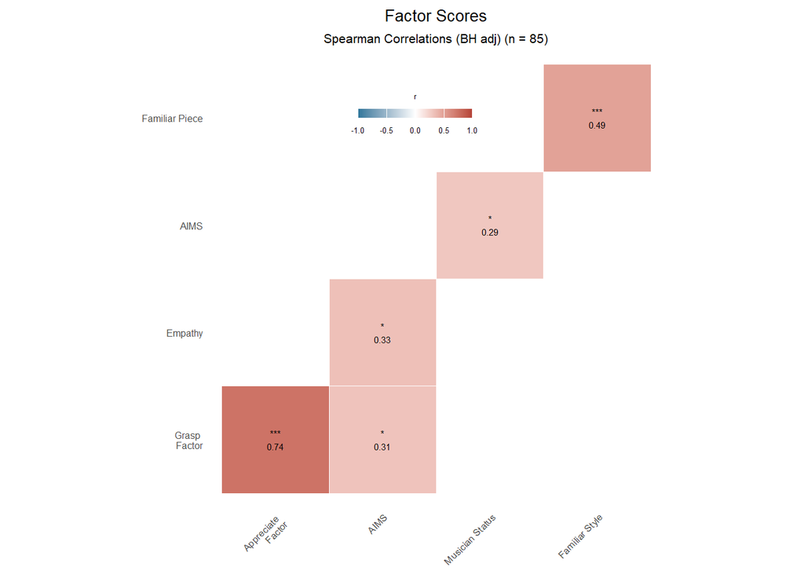

```r
fa_scores<-full_data%>%filter(group == "Live")%>%select(Pt_ID,Grasp, Appreciate)

personal_char_list<-df.full%>%select(Pt_ID, age, EC,AIMS, musician_status, fan, familiar_Bach, style_Bach)

fa_scores_and_pers_chars<-full_join(fa_scores, personal_char_list, by = "Pt_ID")

fa_scores_and_pers_chars_nona<-fa_scores_and_pers_chars%>%select(-age, -Pt_ID)%>%na.omit()

names(fa_scores_and_pers_chars_nona)<-c("Grasp \n Factor", "Appreciate \n Factor", "Empathy", "AIMS", "Musician Status", "Fanship", "Familiar Piece", "Familiar Style")
# check number of samples
samples<-nrow(fa_scores_and_pers_chars_nona)
colours_DSQ<-c("#2d769a", "white","#b34036")
title = "Factor Scores"
# title = "Bach Visualization"
subtitle = paste0("Spearman Correlations (BH adj) (n = ", samples, ")")
chart.correlation.spearman(fa_scores_and_pers_chars_nona, colours_DSQ, title, subtitle) #moved the cross-correlation code to the useful_functions script to make this more tidy.
```

```r
graphname<-paste0("../plots/New_Spearman-Rank-Correlations", title, ".png")
ggsave(graphname,
       width = 10,
       height = 9,
       units = 'cm',
       dpi = 500)
```

## Assess Group differences: Live versus Online

Compare between live and online complex ratings IV: group - Live, Online Complex DV: Grasp, Appreciate

guide: http://www.sthda.com/english/wiki/unpaired-two-samples-wilcoxon-test-in-r

```r
complex_data<-full_data%>%filter(type == "Complex" & order != "second")%>%drop_na(c(Grasp, Appreciate))

#check assumptions
complex_data%>%group_by(group)%>%summarise(W = shapiro.test(Grasp)$statistic,
                                          p = shapiro.test(Grasp)$p.value)
```

| group | W | p |
| --- | --- | --- |
| Live | 0.8635533 | 2.181551e-07 |
| Online | 0.8778192 | 1.098014e-02 |

```r
complex_data%>%group_by(group)%>%summarise(W = shapiro.test(Appreciate)$statistic,p = shapiro.test(Appreciate)$p.value)
```

| group | W | p |
| --- | --- | --- |
| Live | 0.7506068 | 8.901436e-11 |
| Online | 0.9481459 | 2.900710e-01 |

```r
# summarize data
complex_data%>%group_by(group)%>%summarise(n = n())
```

| group | n |
| --- | --- |
| Live | 86 |
| Online | 22 |

```r
## Grasp
complex_data%>%group_by(group)%>%summarise(mean = mean(Grasp), SD = sd(Grasp))
```

| group | mean | SD |
| --- | --- | --- |
| Live | -0.6148821 | 0.9129501 |
| Online | 0.5962391 | 0.7277927 |

```r
## Appreciate
complex_data%>%group_by(group)%>%summarise(mean = mean(Appreciate), SD = sd(Appreciate))
```

| group | mean | SD |
| --- | --- | --- |
| Live | -0.5361548 | 0.778744 |
| Online | 0.4363655 | 1.027105 |

```r
# What are the effects of live versus online on grasping ratings?
wilcox.test(Grasp ~ group, data = complex_data,
                   exact = FALSE)
```

```
##
##  Wilcoxon rank sum test with continuity correction
##
## data:  Grasp by group
## W = 298.5, p-value = 7.961e-07
## alternative hypothesis: true location shift is not equal to 0
```

```r
# What are the effects of live versus online on Appreciate ratings?
wilcox.test(Appreciate ~ group, data = complex_data,
                   exact = FALSE)
```

```
##
##  Wilcoxon rank sum test with continuity correction
##
## data:  Appreciate by group
## W = 418.5, p-value = 5.801e-05
## alternative hypothesis: true location shift is not equal to 0
```

Visualize

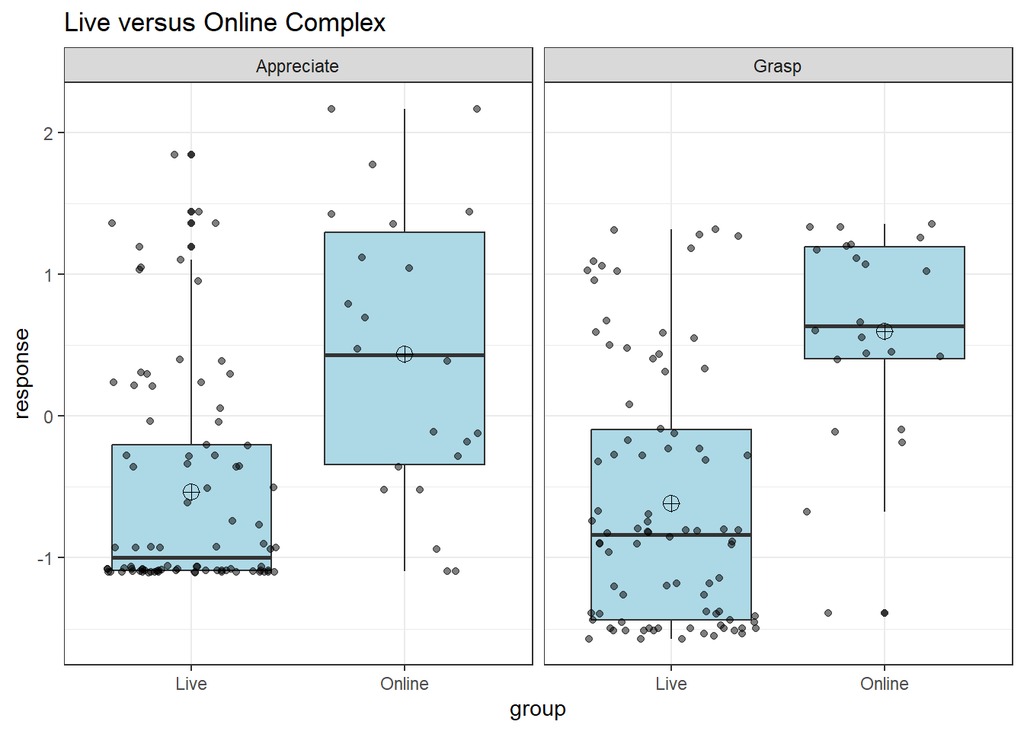

```r
plot_data<-complex_data%>%select(Pt_ID,group, Grasp, Appreciate)

long<-plot_data%>%pivot_longer(!c(Pt_ID, group), names_to = "factor", values_to = "response")

ggplot(long, aes(x = group, y = response)) +
  geom_boxplot(fill = "light blue") +
  geom_jitter(alpha = .5)+
  stat_summary(fun=mean, geom="point", shape=10, size=3.5, color="black") +
  ggtitle("Live versus Online Complex") +
  facet_grid(cols = vars(factor))+
  theme_bw() + theme(legend.position="none")
```

## Complexity differences: Online only

Compare between online simple and online complex ratings IV: type - complex first, Simple first DV: Grasp, Appreciate

Use only the first video they watched

```r
first_data<-full_data%>%filter(group == "Online" & order== "first")%>%drop_na(c(Grasp, Appreciate))

#check assumptions
first_data%>%group_by(type)%>%summarise(W = shapiro.test(Grasp)$statistic,
                                          p = shapiro.test(Grasp)$p.value)
```

| type | W | p |
| --- | --- | --- |
| Complex | 0.8778192 | 0.01098014 |
| Simple | 0.8715541 | 0.00151144 |

```r
# summarize data
first_data%>%group_by(type)%>%summarise(n = n())
```

| type | n |
| --- | --- |
| Complex | 22 |
| Simple | 31 |

```r
## Grasp
first_data%>%group_by(type)%>%summarise(mean = mean(Grasp), SD = sd(Grasp))
```

| type | mean | SD |
| --- | --- | --- |
| Complex | 0.5962391 | 0.7277927 |
| Simple | 0.5879577 | 0.7818280 |

```r
## Appreciate
first_data%>%group_by(group)%>%summarise(mean = mean(Appreciate), SD = sd(Appreciate))
```

| group | mean | SD |
| --- | --- | --- |
| Online | 0.4690316 | 0.9774563 |

```r
# What are the effects of complex versus simple on Grasping ratings?
wilcox.test(Grasp ~ type, data = first_data,
                   exact = FALSE)
```

```
##
##  Wilcoxon rank sum test with continuity correction
##
## data:  Grasp by type
## W = 332, p-value = 0.8781
## alternative hypothesis: true location shift is not equal to 0
```

```r
# What are the effects of live versus online on appreciate ratings?
wilcox.test(Appreciate ~ type, data = first_data,
                   exact = FALSE)
```

```
##
##  Wilcoxon rank sum test with continuity correction
##
## data:  Appreciate by type
## W = 334, p-value = 0.9066
## alternative hypothesis: true location shift is not equal to 0
```

## Compare the groups: SS, SC, CS, CC

Add subgroup class: SS, SC, CS, CC

DV:Grasp and Appreciate IV: type - complex, simple; subgroup random intercept: Pt_ID

```r
## Online: SS, SC, CS, CC
online_dat<-full_data%>%filter(group =="Online")

# join with subgroups df created earlier
online_dat<-online_dat%>%full_join(subgroups, by = "Pt_ID")

online_dat<-online_dat%>%drop_na(Subgroup)
```

Normality is violated in every group

```r
#check assumptions
online_dat%>%group_by(Subgroup)%>%summarise(W = shapiro.test(Grasp)$statistic,
                                          p = shapiro.test(Grasp)$p.value)
```

| Subgroup | W | p |
| --- | --- | --- |
| CC | 0.8755567 | 0.009949166 |
| CS | 0.9059457 | 0.039157601 |
| SC | 0.8377246 | 0.001304646 |
| SS | 0.9183312 | 0.011248510 |

With high sample sizes, the shapiro test is easily violated. Check normality with qqplots.There are minor deviations from normality. Linear mixed effects modeling may be robust against minor deviations to normality, therefore you could still examine if differences could be attributed to subgroup.

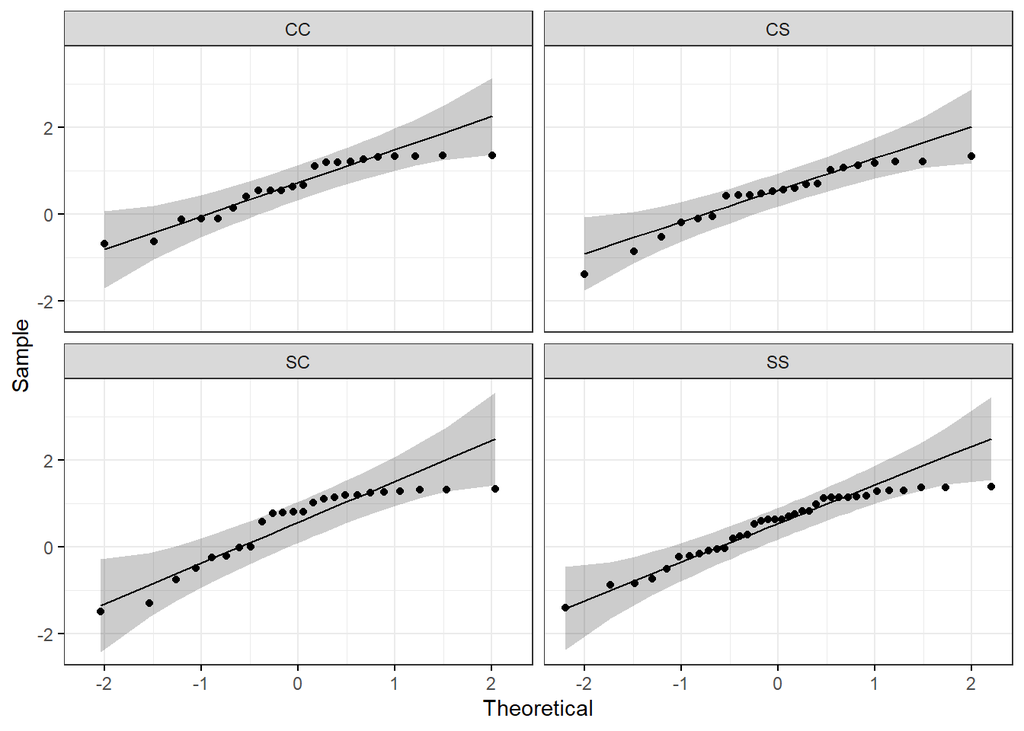

```r
ggqqplot(online_dat, "Grasp", ggtheme = theme_bw(), facet.by = "Subgroup")
```

### LME

Try with lme4 anyways #### Grasp

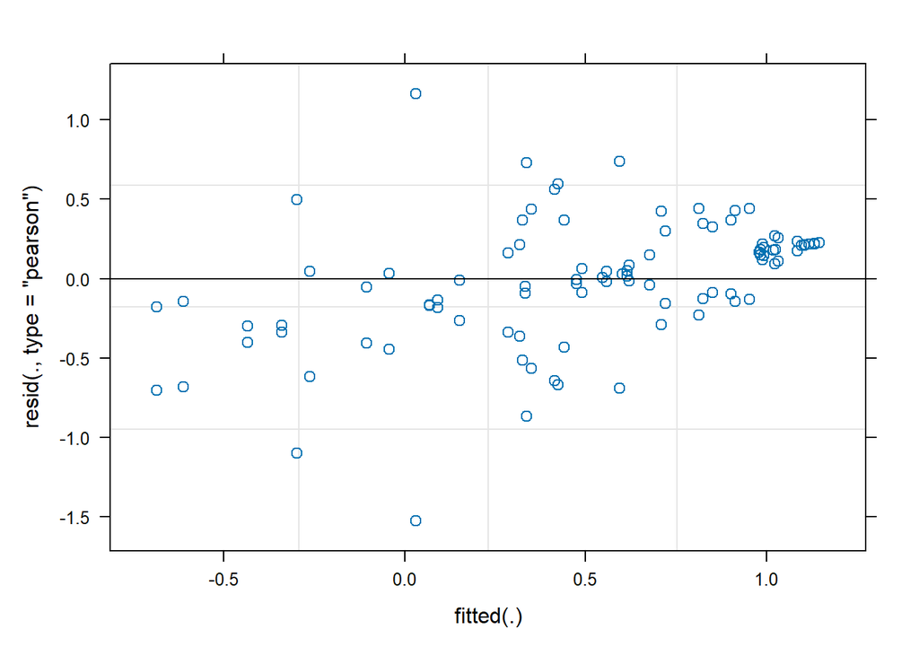

```r
baseline<-lmer(Grasp ~ 1 + (1|Pt_ID), data = online_dat, REML = FALSE)
plot(baseline)
```

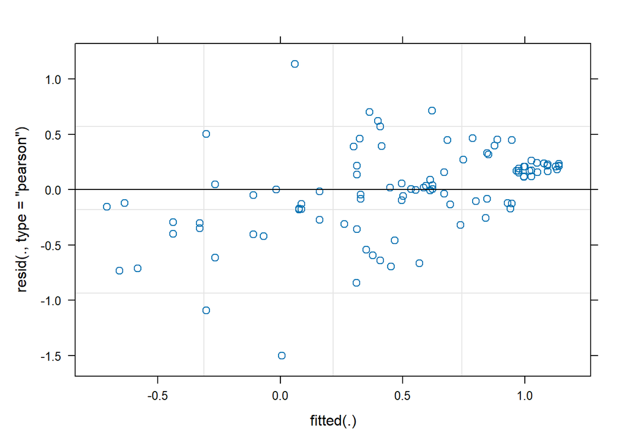

```r
type<-lmer(Grasp ~ 1 + type + (1|Pt_ID), data = online_dat, REML = FALSE)
plot(type)
```

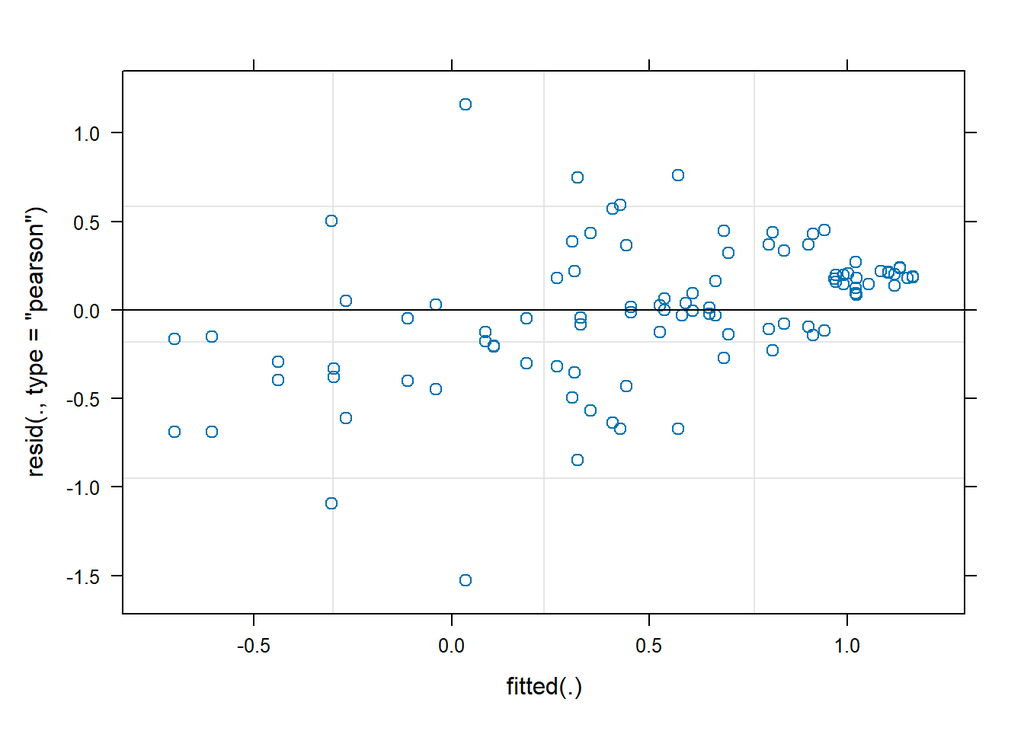

```r
subgroup<-lmer(Grasp ~ 1 + Subgroup + (1|Pt_ID), data = online_dat, REML = FALSE)
plot(subgroup)
```

```r
anova(baseline, type) # ns
```

|  | npar | AIC | BIC | logLik | deviance | Chisq | Df | Pr(>Chisq) |
| --- | --- | --- | --- | --- | --- | --- | --- | --- |
| baseline | 3 | 219.3262 | 227.2594 | -106.6631 | 213.3262 | NA | NA | NA |
| type | 4 | 221.1487 | 231.7263 | -106.5744 | 213.1487 | 0.1775139 | 1 | 0.6735185 |

```r
anova(baseline, subgroup) # ns
```

|  | npar | AIC | BIC | logLik | deviance | Chisq | Df | Pr(>Chisq) |
| --- | --- | --- | --- | --- | --- | --- | --- | --- |
| baseline | 3 | 219.3262 | 227.2594 | -106.6631 | 213.3262 | NA | NA | NA |
| subgroup | 6 | 224.6703 | 240.5367 | -106.3352 | 212.6703 | 0.6559146 | 3 | 0.8835209 |

Check qq

```r
require(lattice)
```

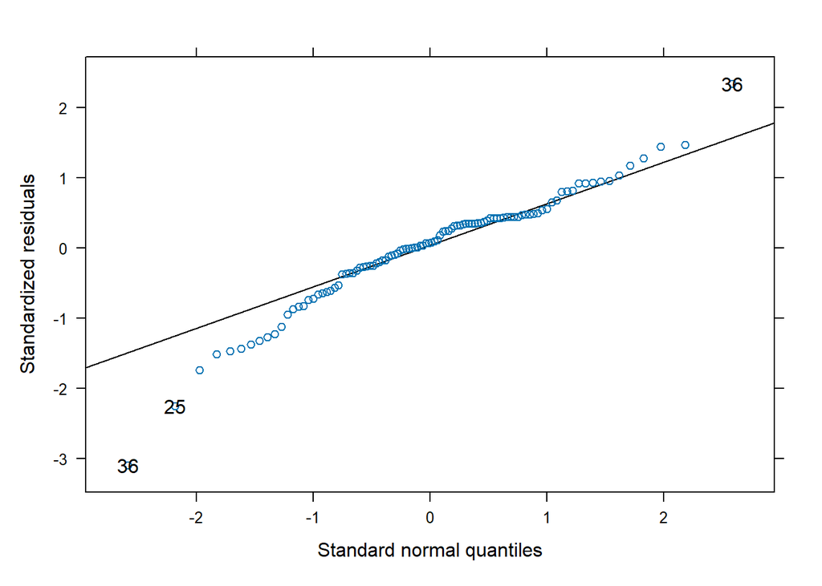

```r
qqmath(type, id=0.05)
```

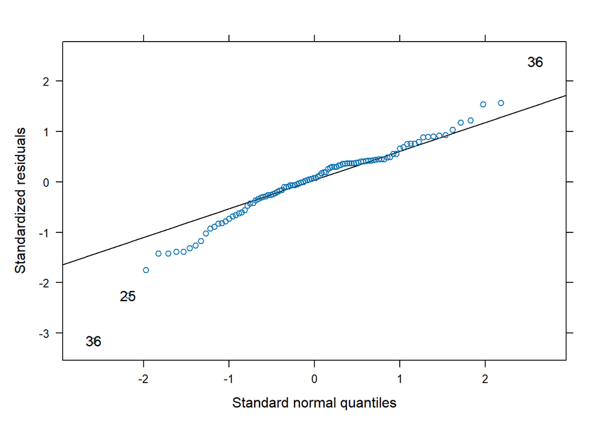

```r
qqmath(subgroup, id=0.05)
```

#### Appreciate

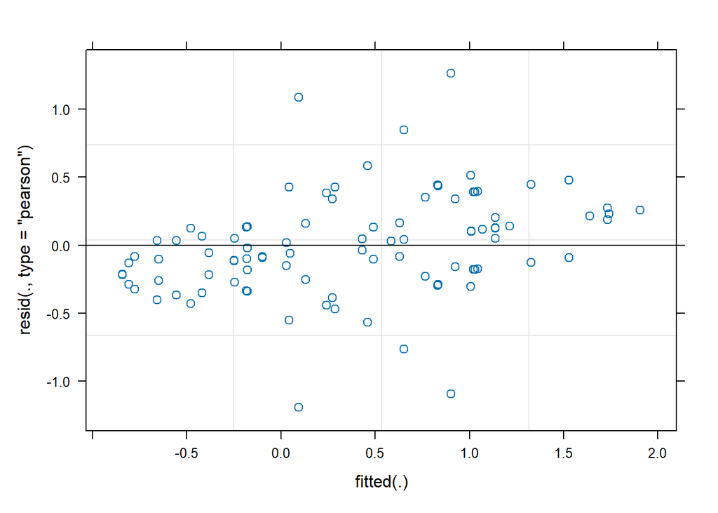

```r
baseline<-lmer(Appreciate ~ 1 + (1|Pt_ID), data = online_dat, REML = FALSE)
plot(baseline)
```

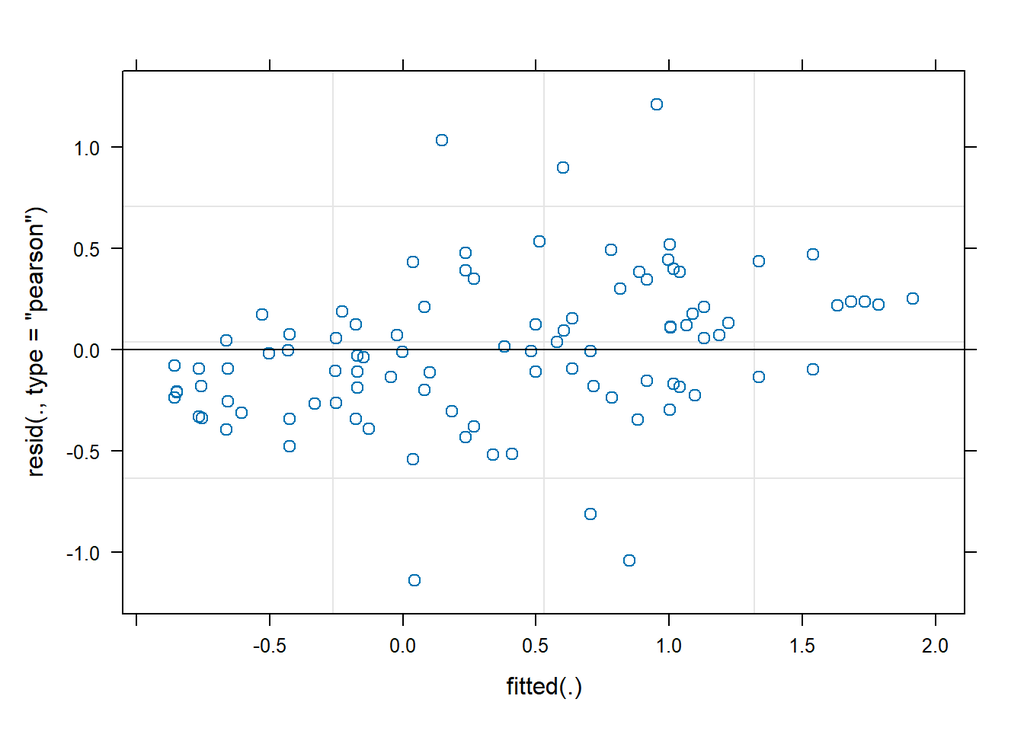

```r
type<-lmer(Appreciate ~ 1 + type + (1|Pt_ID), data = online_dat, REML = FALSE)
plot(type)
```

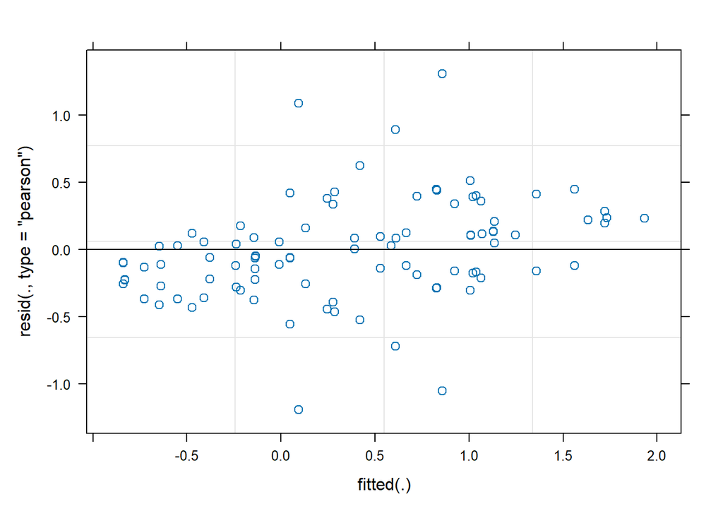

```r
subgroup<-lmer(Appreciate ~ 1 + Subgroup + (1|Pt_ID), data = online_dat, REML = FALSE)
plot(subgroup)
```

```r
anova(baseline, type) # ns
```

|  | npar | AIC | BIC | logLik | deviance | Chisq | Df | Pr(>Chisq) |
| --- | --- | --- | --- | --- | --- | --- | --- | --- |
| baseline | 3 | 245.8662 | 253.7994 | -119.9331 | 239.8662 | NA | NA | NA |
| type | 4 | 247.2353 | 257.8129 | -119.6177 | 239.2353 | 0.6309167 | 1 | 0.4270193 |

```r
anova(baseline, subgroup) # ns
```

|  | npar | AIC | BIC | logLik | deviance | Chisq | Df | Pr(>Chisq) |
| --- | --- | --- | --- | --- | --- | --- | --- | --- |
| baseline | 3 | 245.8662 | 253.7994 | -119.9331 | 239.8662 | NA | NA | NA |
| subgroup | 6 | 249.9311 | 265.7974 | -118.9655 | 237.9311 | 1.935179 | 3 | 0.5859689 |

Visualize

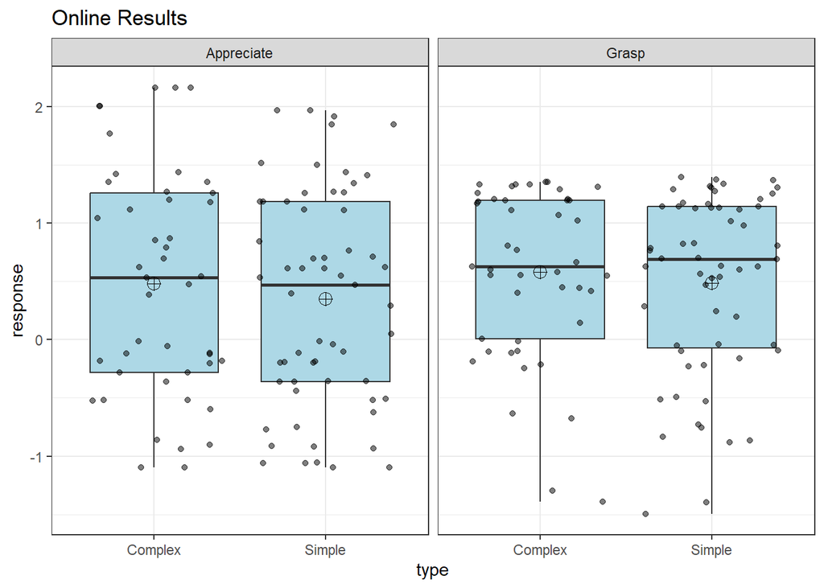

```r
plot_data<-online_dat%>%select(Pt_ID,type, Grasp, Appreciate)

long<-plot_data%>%pivot_longer(!c(Pt_ID, type), names_to = "factor", values_to = "response")

ggplot(long, aes(x = type, y = response)) +
  geom_boxplot(fill = "light blue") +
  geom_jitter(alpha = .5)+
  stat_summary(fun=mean, geom="point", shape=10, size=3.5, color="black") +
  ggtitle("Online Results") +
  facet_grid(cols = vars(factor))+
  theme_bw() + theme(legend.position="none")
```

# Did the visualisation support their Grasping?

```r
# check assumptions
shapiro.test(fa_scores$Grasp) #violated
```

```
##
##  Shapiro-Wilk normality test
##
## data:  fa_scores$Grasp
## W = 0.86355, p-value = 2.182e-07
```

```r
shapiro.test(fa_scores$Appreciate) #violated
```

```
##
##  Shapiro-Wilk normality test
##
## data:  fa_scores$Appreciate
## W = 0.75061, p-value = 8.901e-11
```

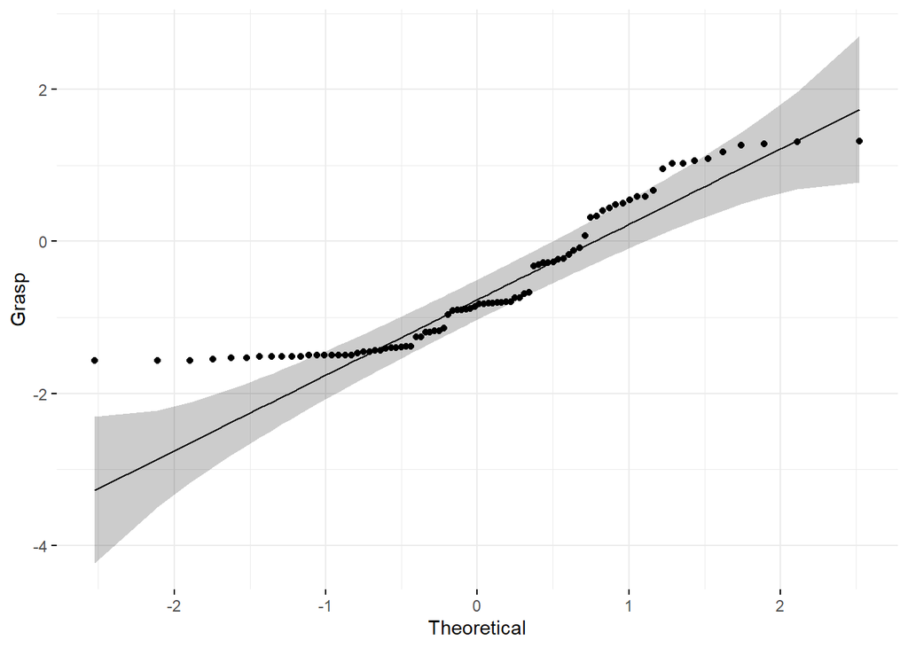

```r
ggqqplot(fa_scores$Grasp, ylab = "Grasp",
         ggtheme = theme_minimal())
```

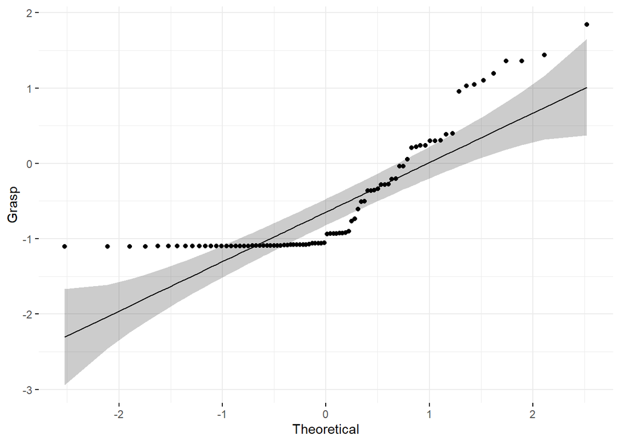

```r
ggqqplot(fa_scores$Appreciate, ylab = "Grasp",
         ggtheme = theme_minimal())
```

```r
#Therefore you need to conduct the One-Sample Wilcoxon Signed Rank Test in R

#live
wilcox.test(fa_scores$Grasp, mu = 0, alternative = "two.sided")
```

```
##
##  Wilcoxon signed rank test with continuity correction
##
## data:  fa_scores$Grasp
## V = 649, p-value = 1.456e-07
## alternative hypothesis: true location is not equal to 0
```

```r
wilcox.test(fa_scores$Appreciate, mu = 0, alternative = "two.sided")
```

```
##
##  Wilcoxon signed rank test with continuity correction
##
## data:  fa_scores$Appreciate
## V = 720, p-value = 7.332e-07
## alternative hypothesis: true location is not equal to 0
```

```r
#online first complex
oneSample <-online_dat%>%filter(order == "first")%>%filter(type =="Complex")

# check assumptions
shapiro.test(oneSample$Grasp) #violated
```

```
##
##  Shapiro-Wilk normality test
##
## data:  oneSample$Grasp
## W = 0.87782, p-value = 0.01098
```

```r
shapiro.test(oneSample$Appreciate) # meets
```

```
##
##  Shapiro-Wilk normality test
##
## data:  oneSample$Appreciate
## W = 0.94815, p-value = 0.2901
```

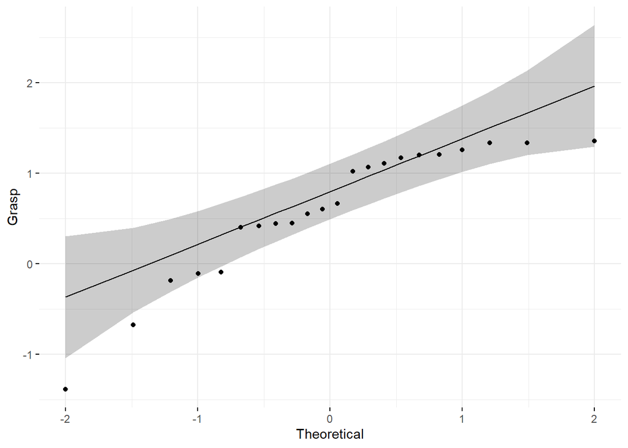

```r
ggqqplot(oneSample$Grasp, ylab = "Grasp",
         ggtheme = theme_minimal())
```

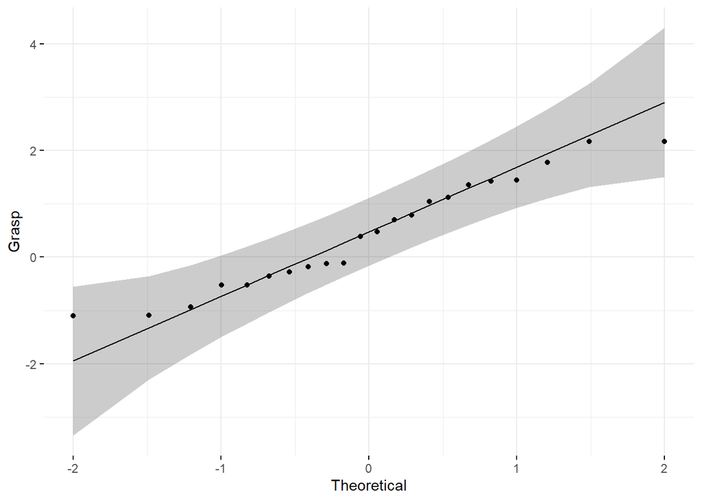

```r
ggqqplot(oneSample$Appreciate, ylab = "Grasp",
         ggtheme = theme_minimal())
```

```r
wilcox.test(oneSample$Grasp, mu = 0, alternative = "two.sided")
```

```
##
##  Wilcoxon signed rank test with continuity correction
##
## data:  oneSample$Grasp
## V = 214, p-value = 0.004733
## alternative hypothesis: true location is not equal to 0
```

```r
t.test(oneSample$Appreciate, mu = 0, alternative = "two.sided")
```

```
##
##  One Sample t-test
##
## data:  oneSample$Appreciate
## t = 1.9927, df = 21, p-value = 0.05945
## alternative hypothesis: true mean is not equal to 0
## 95 percent confidence interval:
##  -0.0190275  0.8917584
## sample estimates:
## mean of x
## 0.4363655
```

```r
#online first simple
oneSample <-online_dat%>%filter(order == "first")%>%filter(type =="Simple")

# check assumptions
shapiro.test(oneSample$Grasp) #violated
```

```
##
##  Shapiro-Wilk normality test
##
## data:  oneSample$Grasp
## W = 0.85952, p-value = 0.0009879
```

```r
shapiro.test(oneSample$Appreciate) # meets
```

```
##
##  Shapiro-Wilk normality test
##
## data:  oneSample$Appreciate
## W = 0.95284, p-value = 0.2013
```

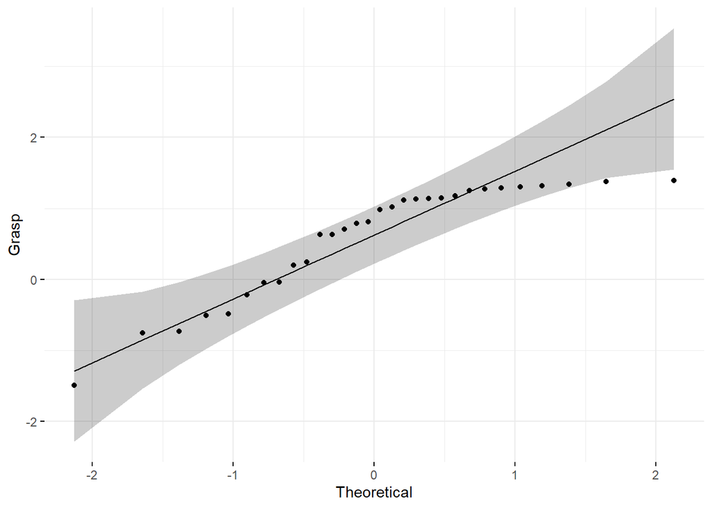

```r
ggqqplot(oneSample$Grasp, ylab = "Grasp",
         ggtheme = theme_minimal())
```

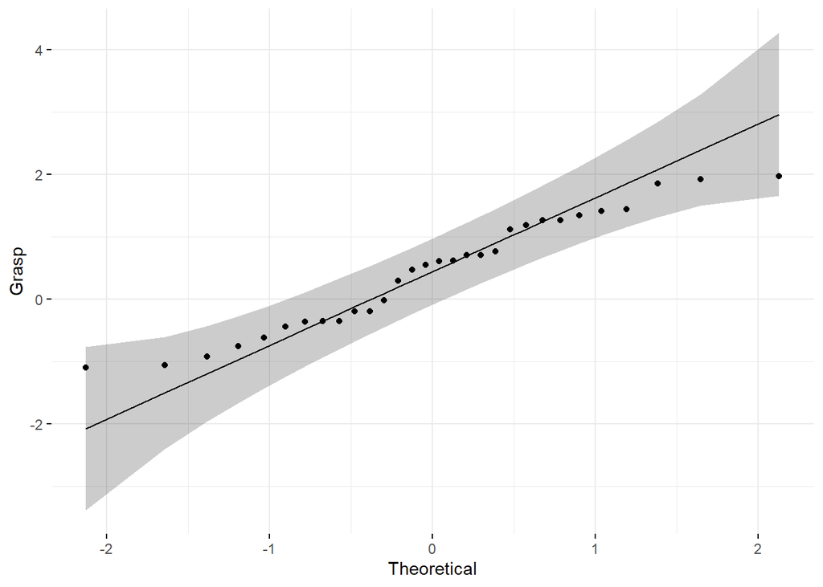

```r
ggqqplot(oneSample$Appreciate, ylab = "Grasp",
         ggtheme = theme_minimal())
```

```r
wilcox.test(oneSample$Grasp, mu = 0, alternative = "two.sided")
```

```
##
##  Wilcoxon signed rank exact test
##
## data:  oneSample$Grasp
## V = 392, p-value = 0.0006084
## alternative hypothesis: true location is not equal to 0
```

```r
t.test(oneSample$Appreciate, mu = 0, alternative = "two.sided")
```

```
##
##  One Sample t-test
##
## data:  oneSample$Appreciate
## t = 2.5963, df = 29, p-value = 0.01464
## alternative hypothesis: true mean is not equal to 0
## 95 percent confidence interval:
##  0.09284324 0.78203524
## sample estimates:
## mean of x
## 0.4374392
```